# Dimension reduction and PCA

Peter Ralph

16 February 2020 – Advanced Biological Statistics

# Multivariate data

We need **multivariate statistics** when we’re dealing with lots (more than one?) variables.

**Goals:** for this and next week:

1. *Describe* and visualize multivariate data.
2. *Distinguish* groups using many variables (e.g., cases from controls).

Both things involve *dimension reduction*, because we see things in ${} \le 3$ dimensions, and categorization is low-dimensional.

## The setting

We have observations of *many variables*:

$$\mathbf{x}_i = (x_{i1}, x_{i2}, \ldots, x_{im}) .$$

so

$$x_{ij} = (\text{measurement of $j^\text{th}$ variable in $i^\text{th}$ subject})$$

```r
head(diabetes, 20)
```

```
##      y     age    sex     bmi     map      tc      ldl      hdl     tch     ltg     glu
## 1  151  0.0381  0.051  0.0617  0.0219 -0.0442 -3.5e-02 -0.04340 -0.0026  0.0199 -0.0176
## 2   75 -0.0019 -0.045 -0.0515 -0.0263 -0.0084 -1.9e-02  0.07441 -0.0395 -0.0683 -0.0922
## 3  141  0.0853  0.051  0.0445 -0.0057 -0.0456 -3.4e-02 -0.03236 -0.0026  0.0029 -0.0259
## 4  206 -0.0891 -0.045 -0.0116 -0.0367  0.0122  2.5e-02 -0.03604  0.0343  0.0227 -0.0094
## 5  135  0.0054 -0.045 -0.0364  0.0219  0.0039  1.6e-02  0.00814 -0.0026 -0.0320 -0.0466
## 6   97 -0.0927 -0.045 -0.0407 -0.0194 -0.0690 -7.9e-02  0.04128 -0.0764 -0.0412 -0.0963
## 7  138 -0.0455  0.051 -0.0472 -0.0160 -0.0401 -2.5e-02  0.00078 -0.0395 -0.0629 -0.0384
## 8   63  0.0635  0.051 -0.0019  0.0666  0.0906  1.1e-01  0.02287  0.0177 -0.0358  0.0031
## 9  110  0.0417  0.051  0.0617 -0.0401 -0.0140  6.2e-03 -0.02867 -0.0026 -0.0150  0.0113
## 10 310 -0.0709 -0.045  0.0391 -0.0332 -0.0126 -3.5e-02 -0.02499 -0.0026  0.0677 -0.0135
## 11 101 -0.0963 -0.045 -0.0838  0.0081 -0.1034 -9.1e-02 -0.01395 -0.0764 -0.0629 -0.0342
## 12  69  0.0272  0.051  0.0175 -0.0332 -0.0071  4.6e-02 -0.06549  0.0712 -0.0964 -0.0591
## 13 179  0.0163 -0.045 -0.0288 -0.0091 -0.0043 -9.8e-03  0.04496 -0.0395 -0.0308 -0.0425
## 14 185  0.0054  0.051 -0.0019  0.0081 -0.0043 -1.6e-02 -0.00290 -0.0026  0.0384 -0.0135
## 15 118  0.0453 -0.045 -0.0256 -0.0126  0.0177 -6.1e-05  0.08177 -0.0395 -0.0320 -0.0756
## 16 171 -0.0527  0.051 -0.0181  0.0804  0.0892  1.1e-01 -0.03972  0.1081  0.0361 -0.0425
## 17 166 -0.0055 -0.045  0.0423  0.0494  0.0246 -2.4e-02  0.07441 -0.0395  0.0523  0.0279
## 18 144  0.0708  0.051  0.0121  0.0563  0.0342  4.9e-02 -0.03972  0.0343  0.0274 -0.0011
## 19  97 -0.0382 -0.045 -0.0105 -0.0367 -0.0373 -1.9e-02 -0.02867 -0.0026 -0.0181 -0.0176
## 20 168 -0.0273 -0.045 -0.0181 -0.0401 -0.0029 -1.1e-02  0.03760 -0.0395 -0.0089 -0.0549
```

```r
head(lizards, 20)
```

```
##     ID Hurricane   Origin    Sex SVL Femur Tibia Metatarsal LongestToe Humerus Radius Metacarpal LongestFinger FingerCount ToeCount MeanFingerArea MeanToeArea
## 1  537     After Pine Cay   Male  49  10.4  11.9        7.5        7.4     8.7    8.0        2.2           3.2          10       12           1.33         2.4
## 2  539     After Pine Cay Female  40   8.7   9.8        6.2        6.2     8.0    6.5        2.4           3.5          10       13           0.96         1.5
## 3  540     After Pine Cay   Male  58  12.9  14.8        9.4        9.6    11.7    9.5        3.5           5.1          14       15           2.63         4.1
## 4  541     After Pine Cay Female  43   8.6  10.3        6.6        6.3     7.4    6.6        2.8           3.5          11       12           1.18         1.9
## 5  542     After Pine Cay Female  46  10.3  11.0        6.9        7.0     7.7    7.2        2.5           3.4          11       13           1.38         2.5
## 6  543     After Pine Cay Female  47  10.0  10.8        6.8        7.2     8.4    7.2        2.4           3.3          12       14           1.43         2.0
## 7  544     After Pine Cay   Male  53  12.7  12.4        7.9        8.2     9.9    8.4        3.1           4.3          11       14           1.86         3.0
## 8  545     After Pine Cay   Male  57  11.9  12.9        8.2        8.0    10.3    8.8        3.2           4.2          12       12           2.56         4.0
## 9  546     After Pine Cay Female  43  10.0  11.1        6.9        6.7     7.8    7.1        2.8           3.4          12       13           1.08         1.8
## 10 547     After Pine Cay   Male  54  11.3  13.1        7.8        7.7    10.2    8.7        3.0           4.1          12       16           2.30         3.9
## 11 548     After Pine Cay Female  41   9.3  10.5        6.7        6.0     7.2    6.8        2.4           2.9          12       13           1.08         1.5
## 12 549     After Pine Cay Female  45   9.2  10.1        6.7        6.5     7.6    6.5        2.7           3.2          11       13           1.31         2.3
## 13 550     After Pine Cay   Male  61  13.9  14.9        8.8        8.4    11.6    9.5        3.0           4.4          13       15           2.47         4.3
## 14 553     After Pine Cay Female  47   9.4  10.6        6.7        6.3     7.8    7.2        2.3           3.3          11       14           1.37         1.9
## 15 554     After Pine Cay   Male  58  11.7  13.8        8.3        8.4    10.8    8.6        3.3           4.1          11       15           2.21         3.6
## 16 555     After Pine Cay   Male  49  10.8  12.2        7.8        7.2     9.0    7.8        2.7           3.6          12       14           1.37         2.2
## 17 558     After Pine Cay   Male  54  12.0  13.3        8.5        8.7     9.8    8.6        2.9           4.1          14       15           2.07         3.6
## 18 559     After Pine Cay   Male  53  11.8  13.0        7.8        7.2     9.6    8.5        2.8           3.8          13       15           1.99         2.9
## 19 560     After Pine Cay   Male  54  12.2  12.9        8.1        8.1     9.9    8.3        2.4           4.1          12       15           1.83         3.2
## 20 561     After Pine Cay Female  41   9.1   9.6        5.9        5.4     6.8    6.4        2.0           3.2          11       11           0.95         1.3
```

# Principal component analysis (PCA)

## Primary aims of PCA

- **Variable reduction** - reduce to a small number of “composite” variables that adequately summarize the original information (*dimension reduction*).
- **Ordination** - Reveal patterns in the data that could not be found by analyzing each variable separately.

## Quick example: diabetes data

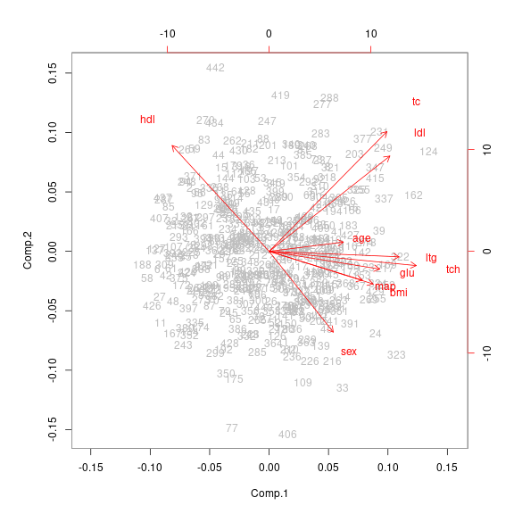

## Quick example: diabetes data

PC1 is correlated with outcome:

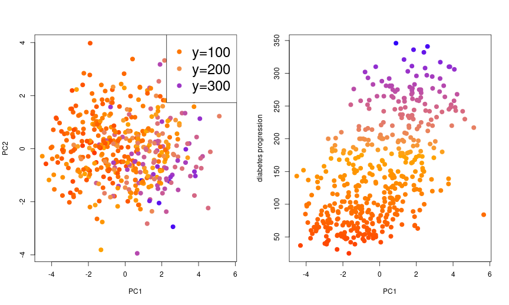

## Quick example: lizards

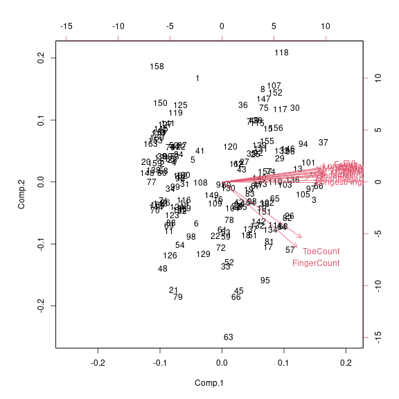

## Quick example: lizards

PC1 is size:

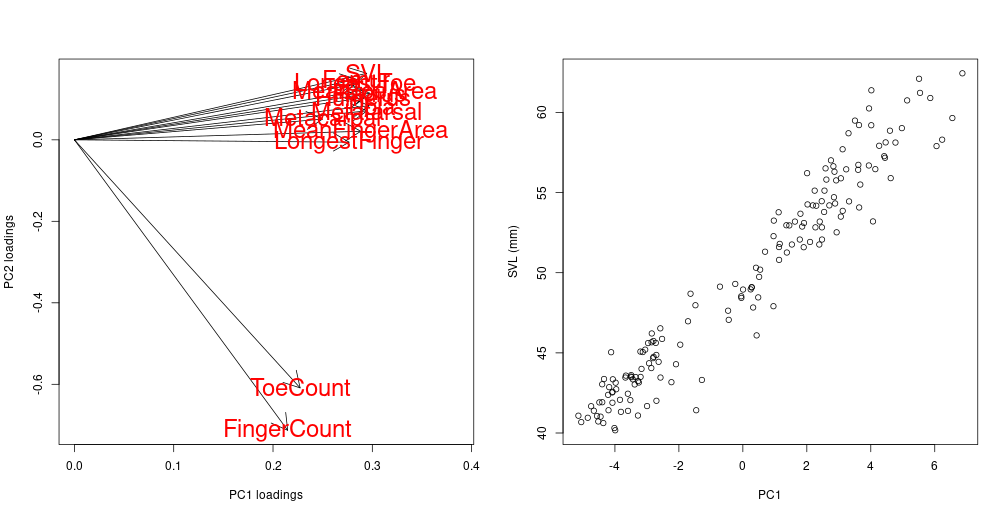

# PCA: how it works

## Reducing dimesions

Say we’ve got a *data matrix* $x_{ij}$ of $n$ observations in $m$ variables,

but we want to make do with *fewer variables* - say, only $k$ of them.

**Idea:** Let’s pick a few linear combinations of the variables that best captures variability within the dataset. For instance, strongly correlated variables will be combined into one.

## Notation:

1. These new variables are the *principal components*,
   $$u^{(1)}, \ldots, u^{(k)} .$$
2. The importance of each variable to the principal components - i.e., the coefficients of the linear combination - are the *loadings*,
   $$v^{(1)}, \ldots, v^{(k)} .$$
3. So, the position of the $i$th data point on the $\ell$th PC is
   $$u_i^{(\ell)} = v_1^{(\ell)} x_{i1} + v_2^{(\ell)} x_{i2} + \cdots v_m^{(\ell)} x_{im} .$$

## Geometric interpretation

1. The loadings are the directions in multidimensional space that explain most variation in the data.
2. The PCs are the coordinates of the data along these directions.
3. These directions are *orthogonal*, and the resulting variables are *uncorrelated*.

## A model for PCA

The *approximation* to the data matrix using only $k$ PCs is:
$$x_{ij} \approx u_i^{(1)} v_j^{(1)} + u_i^{(2)} v_j^{(2)} + \cdots + u_i^{(k)} v_j^{(k)} .$$

This is the *best possible* $k$-dimensional approximation, in the least-squares sense, so is the MLE for the low-dimesional model with Gaussian noise.

## Also known as

PCA is also called “eigenanalysis” because (as usually computed), the PCs are *eigenvectors* of the covariance matrix.

The *eigenvalues* are
$$\lambda_\ell = \sum_{i=1}^n \left(u_i^{(\ell)}\right)^2,$$
and their sum is the *total variance*:
$$\lambda_1 + \lambda_2 + \cdots + \lambda_m
=
\sum_{ij} (x_{ij} - \bar x_j)^2 .$$

## Interpretation

- PCs: Observations that are *close* in PC space are similar.
- Loadings: high values indicate a strong correlation with that PC (positive or negative).

Sometimes PCs are rotated to improve *interpretability*.

## What next?

The PCs are *nice new variables* you can use in any analysis!

Example: Does mouse body size correlate with the top three climate PCs?

# Beer

## Example: local beer

```r
beer <- read.csv("data/Beer_Specs.csv", stringsAsFactors=TRUE)
table(beer$Beer_Type)
```

```
##
##           Ale    Citrus_IPA    Double_IPA        Helles        NW_IPA Oatmeal_Stout   Oktoberfest      Pale_Ale       Red_IPA Vanilla_Stout    Winter_Ale
##            21            14            23            20            94            12             4             8            39            12            10
```

```r
beer_vars <- c("Volume", "CO2", "Color", "DO", "pH", "Bitterness_Units", "ABV", "Real_Extract", "Real_Degrees_Fermentation", "Final_Gravity")
beer[,c("Beer_Type", beer_vars)]
```

```
##         Beer_Type Volume CO2 Color  DO  pH Bitterness_Units ABV Real_Extract Real_Degrees_Fermentation Final_Gravity
## 1             Ale    250 2.4   4.7  80 4.1               56 4.9          3.6                        68             1
## 2             Ale    178 2.4   4.7  86 4.2               53 5.0          3.4                        70             1
## 3             Ale     70 2.4   4.9  89 4.3               61 4.8          3.6                        68             1
## 4             Ale    102 2.4   5.0  89 4.3               58 4.7          3.6                        68             1
## 5             Ale    173 2.4   4.4  82 4.4               59 4.6          3.7                        67             1
## 6             Ale    254 2.4   4.8  94 4.4               57 4.8          3.5                        69             1
## 7             Ale    347 2.4    NA  93 4.2               58 4.7          3.6                        68             1
## 8             Ale    167 2.4   5.2  95 4.2               57 5.2          3.5                        70             1
## 9             Ale    175 2.4   4.8  98 4.2               54 4.8          3.6                        68             1
## 10            Ale    163 2.4   5.0  96 4.3               62 4.9          3.5                        69             1
## 11            Ale    250 2.4   4.7  91 4.3               64 4.7          4.0                        65             1
## 12            Ale    164 2.4   4.7  95 4.3               58 5.1          3.6                        70             1
## 13            Ale    166 2.5   4.5  95 4.2               54 5.0          3.3                        71             1
## 14            Ale    168 2.4   4.9  92 4.3               62 5.0          3.5                        70             1
```

[output cut: 243 more lines]

## Goals:

1. Describe major axes of variation between beer batches.
2. Look for variation not related to taste/style.
3. Make a pretty plot.

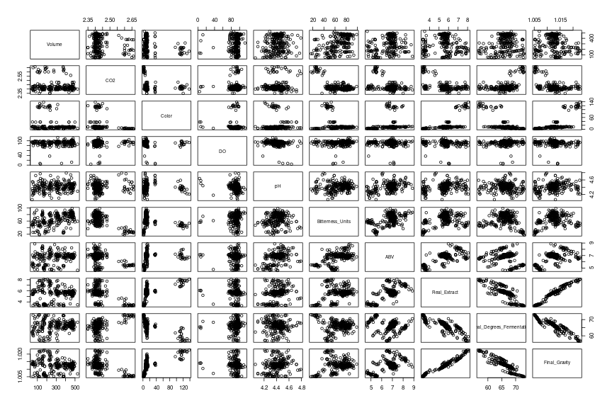

# PCA: how to do it

## Practical considerations

1. Only use **numeric variables** - omit factors.
2. Variables should all be on the **same scale**, at least roughly.
3. Variables should also probably be **centered**.

… however,

4. Beware outliers.
5. Transformations may be a good idea.
6. Missing data must be removed or imputed.
7. Consider replacing highly skewed variables with ranks.

## `?princomp`

```
princomp                 package:stats                 R Documentation

Principal Components Analysis

Description:

     ‘princomp’ performs a principal components analysis on the given
     numeric data matrix and returns the results as an object of class
     ‘princomp’.

Usage:

     princomp(x, ...)

     ## S3 method for class 'formula'
     princomp(formula, data = NULL, subset, na.action, ...)

     ## Default S3 method:
     princomp(x, cor = FALSE, scores = TRUE, covmat = NULL,
              subset = rep_len(TRUE, nrow(as.matrix(x))), fix_sign = TRUE, ...)

     ## S3 method for class 'princomp'
     predict(object, newdata, ...)

Arguments:

 formula: a formula with no response variable, referring only to
          numeric variables.

    data: an optional data frame (or similar: see ‘model.frame’)
          containing the variables in the formula ‘formula’.  By
          default the variables are taken from ‘environment(formula)’.

  subset: an optional vector used to select rows (observations) of the
          data matrix ‘x’.

na.action: a function which indicates what should happen when the data
          contain ‘NA’s.  The default is set by the ‘na.action’ setting
          of ‘options’, and is ‘na.fail’ if that is unset. The
          ‘factory-fresh’ default is ‘na.omit’.
```

[output cut: 88 more lines]

```
     and so may differ between different programs for PCA, and even
     between different builds of R: ‘fix_sign = TRUE’ alleviates that.

References:

     Mardia, K. V., J. T. Kent and J. M. Bibby (1979).  _Multivariate
     Analysis_, London: Academic Press.

     Venables, W. N. and B. D. Ripley (2002).  _Modern Applied
     Statistics with S_, Springer-Verlag.

See Also:

     ‘summary.princomp’, ‘screeplot’, ‘biplot.princomp’, ‘prcomp’,
     ‘cor’, ‘cov’, ‘eigen’.
```

```r
beer_pc <- princomp(na.omit(beer[, beer_vars]), cor=TRUE, scores=TRUE)
str(beer_pc)
```

```
## List of 7
##  $ sdev    : Named num [1:10] 2.05 1.441 1.118 0.965 0.825 ...
##   ..- attr(*, "names")= chr [1:10] "Comp.1" "Comp.2" "Comp.3" "Comp.4" ...
##  $ loadings: 'loadings' num [1:10, 1:10] 0.0194 -0.3338 0.2763 -0.0465 0.1402 ...
##   ..- attr(*, "dimnames")=List of 2
##   .. ..$ : chr [1:10] "Volume" "CO2" "Color" "DO" ...
##   .. ..$ : chr [1:10] "Comp.1" "Comp.2" "Comp.3" "Comp.4" ...
##  $ center  : Named num [1:10] 306.47 2.43 18.12 89.8 4.4 ...
##   ..- attr(*, "names")= chr [1:10] "Volume" "CO2" "Color" "DO" ...
##  $ scale   : Named num [1:10] 134.589 0.0627 29.1922 13.5223 0.1113 ...
##   ..- attr(*, "names")= chr [1:10] "Volume" "CO2" "Color" "DO" ...
##  $ n.obs   : int 223
##  $ scores  : num [1:223, 1:10] -2.98 -3.35 -2.84 -2.77 -2.36 ...
##   ..- attr(*, "dimnames")=List of 2
##   .. ..$ : chr [1:223] "1" "2" "3" "4" ...
##   .. ..$ : chr [1:10] "Comp.1" "Comp.2" "Comp.3" "Comp.4" ...
##  $ call    : language princomp(x = na.omit(beer[, beer_vars]), cor = TRUE, scores = TRUE)
##  - attr(*, "class")= chr "princomp"
```

## What it means

```
> str(beer_pc)
List of 7
```

- `$ sdev`: standard deviations of the PCs
- `$ loadings`: loadings of the variables on each PC
- `$ center`: subtracted from columns of the data
- `$ scale`: divided from columns of the data
- `$ scores`: the actual PCs

## How many PCs should I use?

- PCA gives you as many PCs as variables.

Depends - what for?

Some answers:

1. Visualization: as many as make sense (but beware overinterpretation).
2. Further analysis: as many as your method can handle.
3. Until an obvious break in the *scree plot*.

## The scree plot

Shows the *variance explained by each PC* (these are always decreasing).

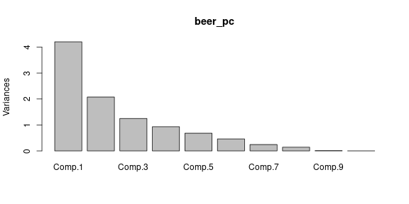

```r
plot(beer_pc)
```

## The top four PCs

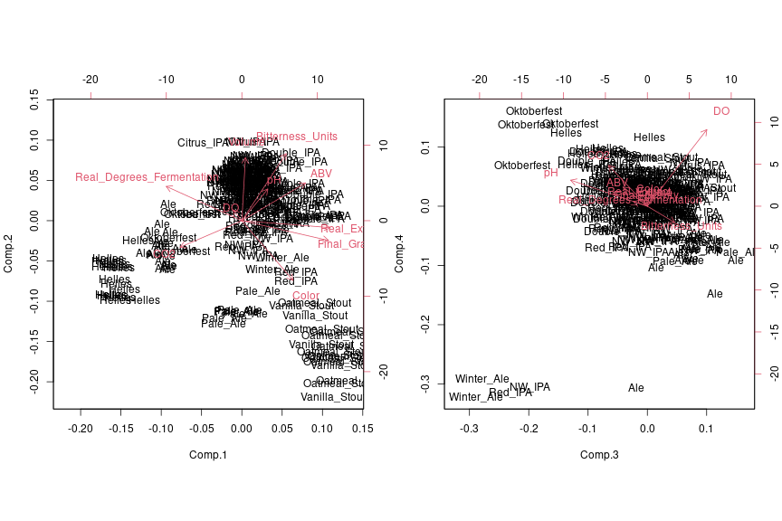

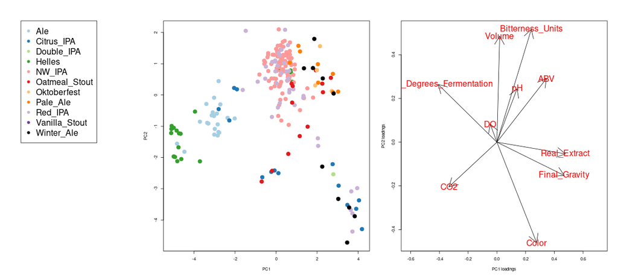

## Gotchas

- PCs are only well-defined up to sign ($\pm$) and scale.
- Some programs report PCs normalized to have SD 1.
- Many ways to do basically the same thing: e.g., `prcomp` and `princomp`.